# Examining NK signature genes in Tirosh et al single cell data

Momeneh (Sepideh) Foroutan and Joseph Cursons

03 May, 2019

# 1 Overview and set up

This document reproduces some of the figures in Cursons et al paper (**A gene signature predicting natural killer cell infiltration and improved survival in melanoma patients**). This includes the analysis of the single cell RNA-seq data from [Tirosh et al](https://www.ncbi.nlm.nih.gov/pubmed/27124452). The single cell data (GSE72056_melanoma_single_cell_revised_v2.txt) were downloaded on 4th of Dec 2018 , and were saved under data folder.

```r
knitr::opts_chunk$set(
  cache = TRUE,
  warning = FALSE,
  message = FALSE)

dataPath   <- "../data/"
scriptPath <- "../script/"
outPath <- "../output/"

library(data.table)
library(Seurat)
library(cowplot)
library(RColorBrewer)
library(limma)
library(dplyr)

source(paste0(scriptPath, "boxplot_vertical_ggplot.R"))

textSize <- 1.6
currentTheme <- theme_minimal() +
  theme(
    ## Set grids
    panel.grid.minor = element_blank(),
    ## Set axis titles
    axis.title = element_text(size = rel(textSize)),
    axis.title.x = element_blank(),
    ## Set axis text
    axis.text.x = element_blank(),
    axis.text.y = element_text(angle = 0, size = rel(textSize)),
    ## Set axis ticks and lines
    axis.ticks = element_line(),
    axis.ticks.x = element_blank(),
    axis.line = element_line(colour = "black"),
    ## Set background colour and text
    strip.background = element_rect(colour = "#f0f0f0", fill = "#f0f0f0"),
    strip.text = element_text(size = rel(textSize)),
    ## Set legend
    legend.position = "bottom",
    legend.direction = "horizontal",
    legend.box = "horizontal",
    legend.title = element_text(face = "italic", size = rel(max(1, textSize * 1.3))),
    legend.text = element_text(size = rel(max(1, textSize * 1.3))),
    legend.margin = margin(unit(0, "cm")),
    legend.key.size = unit(1.5, 'lines'),
    ## Set plot title
    plot.title = element_text(
      face = "bold",
      size = rel(textSize),
      hjust = 0.5
    )
  )
```

# 2 Data preparation

## 2.1 Prepare NK signature genes and expression data

We read the signature and map gene symbols to IDs. Here we use the Homo_sapiens.gene_info file from NCBI which is stored under data folder to do the mapping.

```r
nkSig <- read.csv(paste0(dataPath, "Cursons_Guimaraes_NKsignature_CIR_2019.csv"),
 stringsAsFactors = F)

nk_signature <- nkSig$HGNC.Symbol

## Make sure that we have updated gene symbols
nkIDs <- alias2SymbolUsingNCBI(nk_signature,
  paste0(dataPath, "Homo_sapiens.gene_info"))

nkIDs <- nkIDs[complete.cases(nkIDs$GeneID), ]
```

We read the single cell RNA-seq data from Tirosh et al. Annotation file in Tirosh et al data has several groups: malignant(1 = no, 2 = yes, and 0 = unresolved), and non-malignant cell type (1 = T, 2 = B, 3 = Macro., 4 = Endo., 5 = CAF, and 6 = NK). We replace numbers with meaningful annotations (e.g. cell types).

```r
tirosh <- fread(paste0(dataPath, "Tirosh/GSE72056_melanoma_single_cell_revised_v2.txt"))

tannot <- t(tirosh[1:3, 2:ncol(tirosh)])
colnames(tannot) <- c("Tumour", "Malignant", "Non-malignant")
tannot <- data.frame(tannot)

tannot$Malignant[tannot$Malignant == 1] <- "No"
tannot$Malignant[tannot$Malignant == 2] <- "Yes"
tannot$Malignant[tannot$Malignant == 0] <- "Unresolved"

tannot$Non.malignant[tannot$Non.malignant == 1] <- "T"
tannot$Non.malignant[tannot$Non.malignant == 2] <- "B"
tannot$Non.malignant[tannot$Non.malignant == 3] <- "Macro"
tannot$Non.malignant[tannot$Non.malignant == 4] <- "Endo."
tannot$Non.malignant[tannot$Non.malignant == 5] <- "CAF"
tannot$Non.malignant[tannot$Non.malignant == 6] <- "NK"

tirosh <- tirosh[-c(1,2,3), ]

## remove two duplicated genes
tirosh <- tirosh[! duplicated(tirosh$Cell), ]

rnames <- tirosh$Cell
tirosh <- as.matrix(tirosh[, 2:ncol(tirosh)])
row.names(tirosh) <- rnames
```

Check the table comparing malignant and non-malignant cells.

```r
table(tannot$Malignant,  tannot$Non.malignant)
```

```
##
##                 0    B  CAF Endo. Macro   NK    T
##   No          416  512   56    62   119   51 2040
##   Unresolved   90    3    5     3     6    1   24
##   Yes        1252    0    0     0     1    0    4
```

## 2.2 Generate Seurat object and subset data

```r
## Make a Seurat object
tirosh <- CreateSeuratObject(raw.data = tirosh,
  meta.data = tannot ,
  project = "Tirosh")
tirosh
```

```
## An object of class seurat in project Tirosh
##  23684 genes across 4645 samples.
```

We subset data to only have non-malignant cells. We further remove endothelial cells.

```r
tt0 <- SubsetData(tirosh, cells.use = rownames(tirosh@meta.data[tirosh@meta.data$Malignant == "No", ]), do.clean = TRUE)

tt <- SubsetData(tt0, cells.use = rownames(tt0@meta.data[ ! tt0@meta.data$Non.malignant == "Endo.", ]), do.clean = TRUE)
tt
```

```
## An object of class seurat in project Tirosh
##  23684 genes across 3194 samples.
```

```r
## If data were not normalised
# tt <- NormalizeData(object = tt, normalization.method = "LogNormalize", scale.factor = 10000)
```

We then find the top 1000 most variable genes.

```r
tt <- FindVariableGenes(
  object = tt,
  mean.function = ExpMean,
  dispersion.function = LogVMR,
  do.plot = FALSE)

hv.genes <- head(rownames(tt@hvg.info), 1000)
```

There is no mitochondrial genes in the data to remove.

```r
mito.genes <- grep(pattern = "^MT-", x = rownames(x = tt@data), value = TRUE)
mito.genes
```

```
## character(0)
```

```r
nkIDs$Symbol[!nkIDs$Symbol %in% row.names(tt@data)]
```

```
## [1] "KIR2DL2"  "KIR2DL5A" "KIR2DS2"  "KIR2DS5"  "KLRA1P"   "TRBC1"
## [7] "TRDC"
```

We remove cells with less than 1500 detected genes (n = 1) and more than 10000 genes (n = 14).

```r
## After removing only malignan cells
tt0 <- FilterCells(object = tt0, subset.names = c("nGene"),
    low.thresholds = c(1500), high.thresholds = c(10000))

## After removing Endo cells too
tt <- FilterCells(object = tt, subset.names = c("nGene"),
    low.thresholds = c(1500), high.thresholds = c(10000))
```

## 2.3 Calculate summary stat for NK genes

We calculate some summary statistics for the NK gene expression, including the mean, median, min, max, the 25%-tile and 75%-tile. This helps to compare the expression of a given gene across different cell types.

```r
nkExpr <- tt0@data[intersect(nkIDs$Symbol, row.names(tt0@data)), ]

## Merge expression data for the combined NK signature genes and annotation data
nkExprAnnot <- merge(t(nkExpr), tt0@meta.data, by = "row.names")

## Convert data to long format
nkExprAnnotLong <-
  tidyr::gather(nkExprAnnot, Genes, LogTPM, 2:106, factor_key = TRUE)

nkExprAnnotLong$Non.malignant[nkExprAnnotLong$Non.malignant == "0"] <- "NA"
nkExprAnnotLong$Non.malignant[nkExprAnnotLong$Non.malignant == "Endo."] <- "Endo"

nkExprSummary <- nkExprAnnotLong %>%
  select(Genes, Non.malignant, LogTPM) %>%
  group_by(Non.malignant, Genes) %>%
  mutate(
  min = min(LogTPM),
  firstQ = quantile(LogTPM, probs = 0.25),
  median = median(LogTPM),
  mean = mean(LogTPM),
  thirdQ = quantile(LogTPM, probs = 0.75),
  max = max(LogTPM)
  ) %>%
  ungroup() %>%
  data.frame()


nkExprSummary$Gene_Cell <- paste(
  nkExprSummary$Genes,
  nkExprSummary$Non.malignant,
  sep = "_")

nkExprSummary <- nkExprSummary[
  ! duplicated(nkExprSummary$Gene_Cell), ]

write.table(nkExprSummary, paste0(outPath,
"NK_CombinedSig_GeneSummary_Tirosh.txt"), sep = "\t", row.names = F)
```

CD160 CD244 CTSW FASLG GZMA GZMB GZMH IL18RAP IL2RB KIR2DL4 KLRB1 KLRC3 KLRD1 KLRF1 KLRK1 NCR1 NKG7 PRF1 XCL1 XCL2

# 3 Data visualisation

## 3.1 Boxplots

For the refined NK signature genes proposed by Cursons et al.

```r
nkCursons <- nkSig$HGNC.Symbol[nkSig$Cursons.Guimaraes.sigGene == "TRUE"]

nkExpr <- tt0@data[nkCursons, ]
nkExprAnnot <- merge(t(nkExpr), tt0@meta.data, by = "row.names")

nkExprAnnotLong <-
   tidyr::gather(nkExprAnnot, Genes, LogTPM, CD160:XCL2, factor_key = TRUE)

nkExprAnnotLong$Non.malignant[nkExprAnnotLong$Non.malignant == "0"] <- "Unres"
nkExprAnnotLong$Non.malignant[nkExprAnnotLong$Non.malignant == "Endo."] <- "Endo"

## order genes
nkExprAnnotLong2 <- nkExprAnnotLong[order(nkExprAnnotLong$Genes, decreasing = T), ]
nkExprAnnotLong2$Genes <- factor(nkExprAnnotLong2$Genes,
  levels = unique(as.character(nkExprAnnotLong2$Genes)))
nkExprAnnotLong2$Non.malignant <- factor(nkExprAnnotLong2$Non.malignant,
  levels = c("NK", "CAF", "Macro", "T", "B", "Endo", "Unres"))
```

We Generate vertical boxplots to reproduce **Figure 2A** in Cursons et al paper.

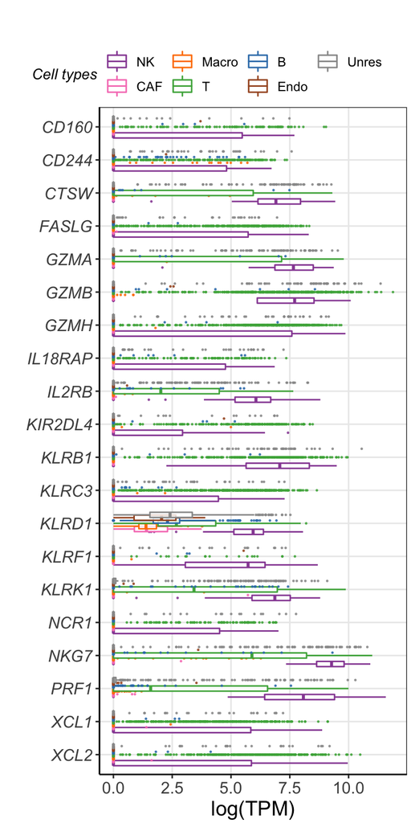

```r
boxplot_vertical_ggplot(
  data = nkExprAnnotLong2,
  x.axis.column = "Genes",
  y.axis.column = "LogTPM",
  annot.column = "Non.malignant",
  title = "",
  cols = brewer.pal(9, "Set1")[c(4, 8, 5, 3, 2, 7, 9)],
  textSize = 1.3
  ) +
  theme(
  plot.margin = unit(c(2, 0.1, 0.1, 0.1),"cm"),
  legend.position = c(0.35, 1.05),
  ## Set legend
  legend.direction = "horizontal",
  legend.box = "horizontal",
  legend.margin = margin(unit(0, "cm")),
  legend.key.size = unit(1.2, 'lines')
  )
```

We can also generate horizontal boxplots, as shown below.

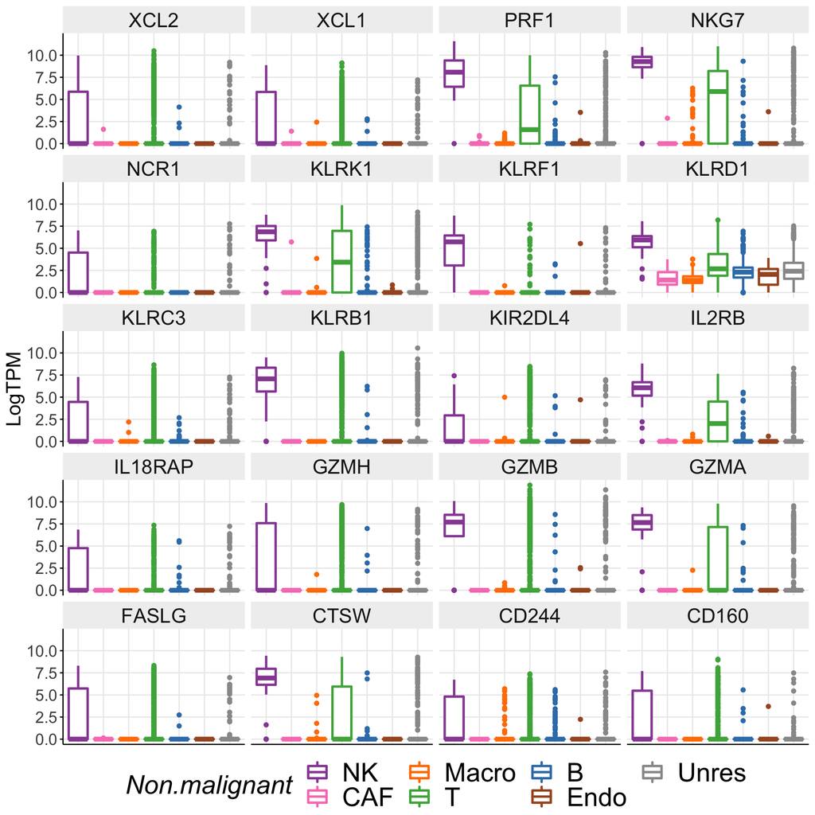

```r
ggplot(nkExprAnnotLong2,
  aes(x = Non.malignant,
    y = LogTPM,
    color = Non.malignant)) +
  geom_boxplot(size = 1) +
  facet_wrap(~ Genes, ncol = 4) +
  scale_color_manual(values = brewer.pal(9, "Set1")[c(4, 8, 5, 3, 2, 7, 9)]) +
  currentTheme
```

## 3.2 PCA plots

For the PCA and tSNE plots, we use the data after filtering endothelial cells for better visualisations. This is because Endo cells are very different from the rest of the cell types.

```r
tt <- ScaleData(
  object = tt,
  genes.use = hv.genes,
  display.progress = FALSE,
  # vars.to.regress = "percent.mito",
  do.par = TRUE,
  num.cores = 6)
```

```
## NormalizeData has not been run, therefore ScaleData is running on non-normalized values. Recommended workflow is to run NormalizeData first.
## ScaleData is running on non-normalized values. Recommended workflow is to run NormalizeData first.
```

```r
tt <- RunPCA(
  object = tt,
  pc.genes = hv.genes,
  pcs.compute = 100,
  do.print = FALSE,
  pcs.print = 1:5,
  genes.print = 5)
```

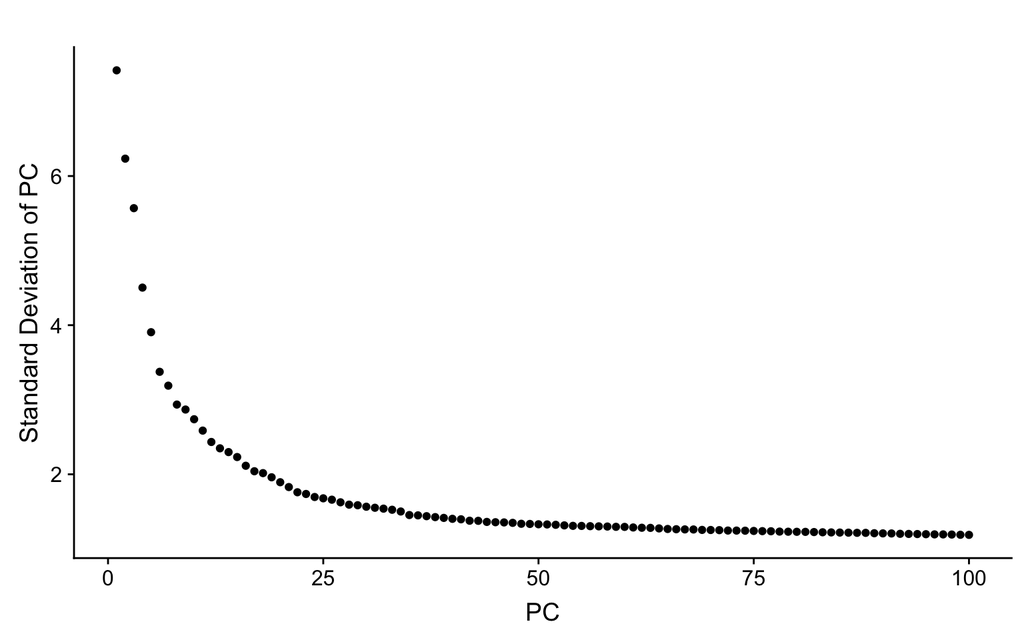

```r
PCElbowPlot(object = tt, num.pc = 100)
```

We select 50 PCs for the downstream analysis. Here are the plots for the first 3 and last 3 PCs from PC 1 to 50.

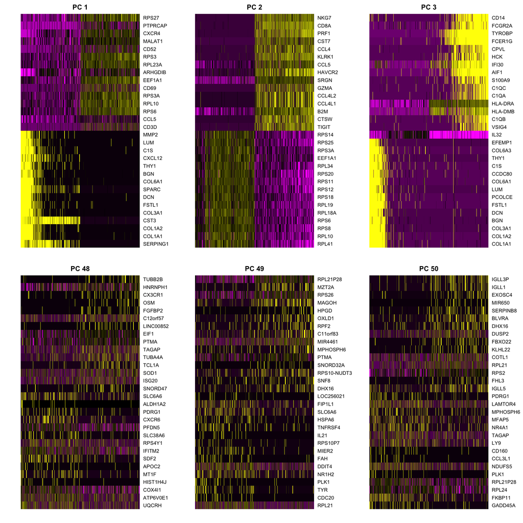

```r
PCHeatmap(tt, pc.use = c(1:3, 48:50), cells.use = 500, do.balanced = TRUE)
```

## 3.3 tSNE plots

For resolution, we can use a value above 1.0 to obtain a larger number of communities, or below 1 for smaller number of communities.

```r
tt <- FindClusters(
  object = tt,
  reduction.type = "pca",
  dims.use = 1:50,
  resolution = 1,
  save.SNN = TRUE,
  n.start = 100,
  # nn.eps = 0.1,
  print.output = FALSE)
```

Then we run tSNE using the first 50 PCs, and perplexity of 50.

```r
set.seed(100)
tt <- RunTSNE(object = tt,
  reduction.use = "pca",
  dims.use = 1:50,
  tsne.method = "Rtsne",
  nthreads = 6,
  perplexity = 50,
  max_iter = 2000)
```

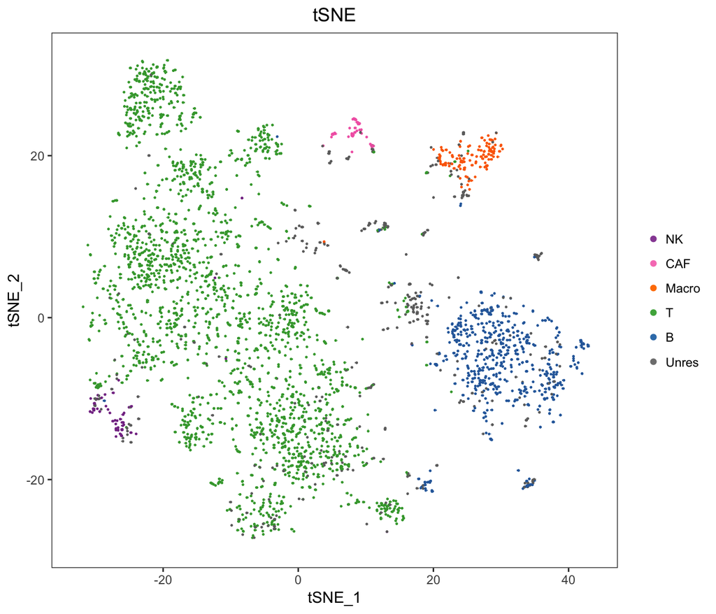

```r
tt@meta.data$Non.malignant[tt@meta.data$Non.malignant == "0"] <- "Unres"
tt@meta.data$Non.malignant<- factor(tt@meta.data$Non.malignant, levels = c("NK", "CAF", "Macro", "T", "B", "Unres"))

p1 <- DimPlot(
  object = tt,
  reduction.use = "tsne",
  cols.use = brewer.pal(8, "Set1")[c(4, 8, 5, 3, 2, 9)],
  group.by = "Non.malignant",
  do.return = TRUE,
  vector.friendly = TRUE,
  pt.size = 1) +
  ggtitle("tSNE") +
  guides(color=guide_legend("Cell type")) +
  theme(plot.title = element_text(hjust = 0.5))

p1
```